# Project with Arvato: Identify Customer Segments

Applied unsupervised learning techniques to identify segments of the population that form the core customer base for a mail-order sales company in Germany, [Arvato-Bertelsmann](https://www.bertelsmann.com/divisions/arvato/#st-1). These segments can then be used to direct marketing campaigns towards audiences that will have the highest expected rate of returns. The data that you will use has been provided by our partners at Bertelsmann Arvato Analytics, and represents a real-life data science task.

## Index

- Step 0: Load the Data
- Step 1: Preprocessing
  - Step 1.1: Assess Missing Data
  - Step 1.2: Select and Re-Encode Features
  - Step 1.3: Create a Cleaning Function
- Step 2: Feature Transformation
  - Step 2.1: Apply Feature Scaling
  - Step 2.2: Perform Dimensionality Reduction
  - Step 2.3: Interpret Principal Components
- Step 3: Clustering
  - Step 3.1: Apply Clustering to General Population
  - Step 3.2: Apply All Steps to the Customer Data
  - Step 3.3: Compare Customer Data to Demographics Data

```python
# import libraries
import numpy as np
import pandas as pd
import matplotlib.pyplot as plt
import seaborn as sns

from sklearn.preprocessing import StandardScaler
from sklearn.decomposition import PCA
from sklearn.cluster import KMeans

# magic word for producing visualizations in notebook
%matplotlib inline
custom_params = {"axes.spines.right": False, "axes.spines.top": False, 'grid.linestyle': '--','figure.figsize': [12, 8], 'font.size': 12}
sns.set_theme(style='ticks', rc=custom_params)

#display options
from IPython.display import display
pd.options.display.max_columns = 500
pd.options.display.max_rows = 500

#warnings filtering
import warnings
warnings.simplefilter(action='ignore', category=FutureWarning)
warnings.simplefilter(action='ignore', category=RuntimeWarning)
```

### Step 0: Load the Data

There are four files associated with this project (besides this .ipynb):

- `Udacity_AZDIAS_Subset.csv`: Demographics data for the general population of Germany; 891211 persons (rows) x 85 features (columns).
- `Udacity_CUSTOMERS_Subset.csv`: Demographics data for customers of a mail-order company; 191652 persons (rows) x 85 features (columns).
- `Data_Dictionary.md`: Detailed information file about the features in the provided datasets.
- `AZDIAS_Feature_Summary.csv`: Summary of feature attributes for demographics data; 85 features (rows) x 4 columns

Go back to Index

```python
# Load in the general demographics data.
azdias = pd.read_csv('Udacity_AZDIAS_Subset.csv', delimiter=';')

# Load in the feature summary file.
feat_info = pd.read_csv('AZDIAS_Feature_Summary.csv', delimiter=';')
```

```python
# Check the structure of the data
print('Demographics Data:\n',azdias.shape,'\n','\n')
display(azdias.describe(include='all'))
print('\n')
azdias.head()
```

```
Demographics Data:
 (891221, 85)
```

|  | AGER_TYP | ALTERSKATEGORIE_GROB | ANREDE_KZ | CJT_GESAMTTYP | FINANZ_MINIMALIST | FINANZ_SPARER | FINANZ_VORSORGER | FINANZ_ANLEGER | FINANZ_UNAUFFAELLIGER | FINANZ_HAUSBAUER | FINANZTYP | GEBURTSJAHR | GFK_URLAUBERTYP | GREEN_AVANTGARDE | HEALTH_TYP | LP_LEBENSPHASE_FEIN | LP_LEBENSPHASE_GROB | LP_FAMILIE_FEIN | LP_FAMILIE_GROB | LP_STATUS_FEIN | LP_STATUS_GROB | NATIONALITAET_KZ | PRAEGENDE_JUGENDJAHRE | RETOURTYP_BK_S | SEMIO_SOZ | SEMIO_FAM | SEMIO_REL | SEMIO_MAT | SEMIO_VERT | … |
| --- | --- | --- | --- | --- | --- | --- | --- | --- | --- | --- | --- | --- | --- | --- | --- | --- | --- | --- | --- | --- | --- | --- | --- | --- | --- | --- | --- | --- | --- | --- |
| count | 891221.000000 | 891221.000000 | 891221.000000 | 886367.000000 | 891221.000000 | 891221.000000 | 891221.000000 | 891221.000000 | 891221.000000 | 891221.000000 | 891221.000000 | 891221.000000 | 886367.000000 | 891221.000000 | 891221.000000 | 886367.000000 | 886367.000000 | 886367.000000 | 886367.000000 | 886367.000000 | 886367.000000 | 891221.000000 | 891221.000000 | 886367.000000 | 891221.000000 | 891221.000000 | 891221.000000 | 891221.000000 | 891221.000000 | … |
| unique | NaN | NaN | NaN | NaN | NaN | NaN | NaN | NaN | NaN | NaN | NaN | NaN | NaN | NaN | NaN | NaN | NaN | NaN | NaN | NaN | NaN | NaN | NaN | NaN | NaN | NaN | NaN | NaN | NaN | … |
| top | NaN | NaN | NaN | NaN | NaN | NaN | NaN | NaN | NaN | NaN | NaN | NaN | NaN | NaN | NaN | NaN | NaN | NaN | NaN | NaN | NaN | NaN | NaN | NaN | NaN | NaN | NaN | NaN | NaN | … |
| freq | NaN | NaN | NaN | NaN | NaN | NaN | NaN | NaN | NaN | NaN | NaN | NaN | NaN | NaN | NaN | NaN | NaN | NaN | NaN | NaN | NaN | NaN | NaN | NaN | NaN | NaN | NaN | NaN | NaN | … |
| mean | -0.358435 | 2.777398 | 1.522098 | 3.632838 | 3.074528 | 2.821039 | 3.401106 | 3.033328 | 2.874167 | 3.075121 | 3.790586 | 1101.178533 | 7.350304 | 0.196612 | 1.792102 | 14.622637 | 4.453621 | 3.599574 | 2.185966 | 4.791151 | 2.432575 | 1.026827 | 8.154346 | 3.419630 | 3.945860 | 4.272729 | 4.240609 | 4.001597 | 4.023709 | … |
| std | 1.198724 | 1.068775 | 0.499512 | 1.595021 | 1.321055 | 1.464749 | 1.322134 | 1.529603 | 1.486731 | 1.353248 | 1.987876 | 976.583551 | 3.525723 | 0.397437 | 1.269062 | 12.616883 | 3.855639 | 3.926486 | 1.756537 | 3.425305 | 1.474315 | 0.586634 | 4.844532 | 1.417741 | 1.946564 | 1.915885 | 2.007373 | 1.857540 | 2.077746 | … |
| min | -1.000000 | 1.000000 | 1.000000 | 1.000000 | 1.000000 | 1.000000 | 1.000000 | 1.000000 | 1.000000 | 1.000000 | 1.000000 | 0.000000 | 1.000000 | 0.000000 | -1.000000 | 0.000000 | 0.000000 | 0.000000 | 0.000000 | 1.000000 | 1.000000 | 0.000000 | 0.000000 | 1.000000 | 1.000000 | 1.000000 | 1.000000 | 1.000000 | 1.000000 | … |
| 25% | -1.000000 | 2.000000 | 1.000000 | 2.000000 | 2.000000 | 1.000000 | 3.000000 | 2.000000 | 2.000000 | 2.000000 | 2.000000 | 0.000000 | 5.000000 | 0.000000 | 1.000000 | 4.000000 | 1.000000 | 1.000000 | 1.000000 | 2.000000 | 1.000000 | 1.000000 | 5.000000 | 2.000000 | 2.000000 | 3.000000 | 3.000000 | 2.000000 | 2.000000 | … |
| 50% | -1.000000 | 3.000000 | 2.000000 | 4.000000 | 3.000000 | 3.000000 | 3.000000 | 3.000000 | 3.000000 | 3.000000 | 4.000000 | 1943.000000 | 8.000000 | 0.000000 | 2.000000 | 11.000000 | 3.000000 | 1.000000 | 1.000000 | 4.000000 | 2.000000 | 1.000000 | 8.000000 | 3.000000 | 4.000000 | 4.000000 | 4.000000 | 4.000000 | 4.000000 | … |
| 75% | -1.000000 | 4.000000 | 2.000000 | 5.000000 | 4.000000 | 4.000000 | 5.000000 | 5.000000 | 4.000000 | 4.000000 | 6.000000 | 1970.000000 | 10.000000 | 0.000000 | 3.000000 | 27.000000 | 8.000000 | 8.000000 | 4.000000 | 9.000000 | 4.000000 | 1.000000 | 14.000000 | 5.000000 | 6.000000 | 6.000000 | 6.000000 | 5.000000 | 6.000000 | … |
| max | 3.000000 | 9.000000 | 2.000000 | 6.000000 | 5.000000 | 5.000000 | 5.000000 | 5.000000 | 5.000000 | 5.000000 | 6.000000 | 2017.000000 | 12.000000 | 1.000000 | 3.000000 | 40.000000 | 12.000000 | 11.000000 | 5.000000 | 10.000000 | 5.000000 | 3.000000 | 15.000000 | 5.000000 | 7.000000 | 7.000000 | 7.000000 | 7.000000 | 7.000000 | … |

|  | AGER_TYP | ALTERSKATEGORIE_GROB | ANREDE_KZ | CJT_GESAMTTYP | FINANZ_MINIMALIST | FINANZ_SPARER | FINANZ_VORSORGER | FINANZ_ANLEGER | FINANZ_UNAUFFAELLIGER | FINANZ_HAUSBAUER | FINANZTYP | GEBURTSJAHR | GFK_URLAUBERTYP | GREEN_AVANTGARDE | HEALTH_TYP | LP_LEBENSPHASE_FEIN | LP_LEBENSPHASE_GROB | LP_FAMILIE_FEIN | LP_FAMILIE_GROB | LP_STATUS_FEIN | LP_STATUS_GROB | NATIONALITAET_KZ | PRAEGENDE_JUGENDJAHRE | RETOURTYP_BK_S | SEMIO_SOZ | SEMIO_FAM | SEMIO_REL | SEMIO_MAT | SEMIO_VERT | … |
| --- | --- | --- | --- | --- | --- | --- | --- | --- | --- | --- | --- | --- | --- | --- | --- | --- | --- | --- | --- | --- | --- | --- | --- | --- | --- | --- | --- | --- | --- | --- |
| 0 | -1 | 2 | 1 | 2.0 | 3 | 4 | 3 | 5 | 5 | 3 | 4 | 0 | 10.0 | 0 | -1 | 15.0 | 4.0 | 2.0 | 2.0 | 1.0 | 1.0 | 0 | 0 | 5.0 | 2 | 6 | 7 | 5 | 1 | … |
| 1 | -1 | 1 | 2 | 5.0 | 1 | 5 | 2 | 5 | 4 | 5 | 1 | 1996 | 10.0 | 0 | 3 | 21.0 | 6.0 | 5.0 | 3.0 | 2.0 | 1.0 | 1 | 14 | 1.0 | 5 | 4 | 4 | 3 | 1 | … |
| 2 | -1 | 3 | 2 | 3.0 | 1 | 4 | 1 | 2 | 3 | 5 | 1 | 1979 | 10.0 | 1 | 3 | 3.0 | 1.0 | 1.0 | 1.0 | 3.0 | 2.0 | 1 | 15 | 3.0 | 4 | 1 | 3 | 3 | 4 | … |
| 3 | 2 | 4 | 2 | 2.0 | 4 | 2 | 5 | 2 | 1 | 2 | 6 | 1957 | 1.0 | 0 | 2 | 0.0 | 0.0 | 0.0 | 0.0 | 9.0 | 4.0 | 1 | 8 | 2.0 | 5 | 1 | 2 | 1 | 4 | … |
| 4 | -1 | 3 | 1 | 5.0 | 4 | 3 | 4 | 1 | 3 | 2 | 5 | 1963 | 5.0 | 0 | 3 | 32.0 | 10.0 | 10.0 | 5.0 | 3.0 | 2.0 | 1 | 8 | 5.0 | 6 | 4 | 4 | 2 | 7 | … |

#### Observations:

> - Demographics data for the general population of Germany
> - Includes 891211 persons (rows) x 85 features (columns)
> - Some features have missing values (i.e. RETOURTYP_BK_S)
> - Other features have (what seems) outliers (i.e. ANZ_HAUSHALTE_AKTIV)

```python
print('Features Summary:\n',feat_info.shape,'\n','\n')
display(feat_info.describe())
print('\n')
feat_info.head()
```

```
Features Summary:
 (85, 4)
```

|  | attribute | information_level | type | missing_or_unknown |
| --- | --- | --- | --- | --- |
| count | 85 | 85 | 85 | 85 |
| unique | 85 | 9 | 5 | 9 |
| top | HEALTH_TYP | person | ordinal | [-1] |
| freq | 1 | 43 | 49 | 26 |

|  | attribute | information_level | type | missing_or_unknown |
| --- | --- | --- | --- | --- |
| 0 | AGER_TYP | person | categorical | [-1,0] |
| 1 | ALTERSKATEGORIE_GROB | person | ordinal | [-1,0,9] |
| 2 | ANREDE_KZ | person | categorical | [-1,0] |
| 3 | CJT_GESAMTTYP | person | categorical | [0] |
| 4 | FINANZ_MINIMALIST | person | ordinal | [-1] |

```python
display(feat_info.information_level.unique())
display(feat_info.type.unique())
```

```
array(['person', 'household', 'building', 'microcell_rr4',
       'microcell_rr3', 'postcode', 'region_rr1', 'macrocell_plz8',
       'community'], dtype=object)
```

```
array(['categorical', 'ordinal', 'numeric', 'mixed', 'interval'],
      dtype=object)
```

#### Observations:

> - Summary of feature attributes for demographics data
> - It includes 85 features (one per column in azdias df) x 4 columns(attribute, information_level, type and missing_or_unknown)
> - Information_level let us know what kind of population info is included in azdias df: personal info, household, address...
> - Demographics attributes data types: Categorical, ordinal, numeric, mixed and interval.

## Step 1: Preprocessing

### Step 1.1: Assess Missing Data

The feature summary file contains a summary of properties for each demographics data column. This file will help us to make cleaning decisions during this stage of the project, while assessing the demographics data in terms of missing data.

#### Step 1.1.1: Convert Missing Value Codes to NaNs

The fourth column of the feature attributes summary (loaded in above as `feat_info`) documents the codes from the data dictionary that indicate missing or unknown data. While the file encodes this as a list (e.g. `[-1,0]`), this will get read in as a string object. We'll do a little bit of parsing to make use of it to identify and clean the data.

Go back to Index

```python
# Identify missing or unknown data values and convert them to NaNs.

def mapping_nan(df, mapper, mapper_column_name, mapper_column_definition, non_numerical_indicators=[]):
    # For each mapper_df row definition
    for index, row in mapper.iterrows():

        # Omit rows with no NaNs or with lists without values
        if len(row[mapper_column_definition]) > 0 and row[mapper_column_definition] != ['']:
            try:
                # For each column definition build a list of nan_indicators
                replace_mask = []
                for nan_indicator in row[mapper_column_definition]:

                    if nan_indicator in non_numerical_indicators:
                        replace_mask.append(nan_indicator)
                    else:
                        replace_mask.append(int(nan_indicator))

                # Replace masked values with NaN
                df[row[mapper_column_name]] = df[row[mapper_column_name]].replace(replace_mask, np.nan)

            except Exception as e:
                print('Exception: {} -> {} --> {}'.format(row[mapper_column_name], str(e), nan_indicator))
                continue

    return df
```

```python
# Remove brackets and split strings into lists in feat_info.missing_or_unknown
feat_info.missing_or_unknown = feat_info.missing_or_unknown.str.strip('[').str.strip(']').str.split(',')
```

```python
# Replace with NaNs all values per mapping in feat_info
azdias = mapping_nan(azdias, feat_info, 'attribute', 'missing_or_unknown', non_numerical_indicators=['X', 'XX'])
```

```python
# Checking result
azdias.head()
```

|  | AGER_TYP | ALTERSKATEGORIE_GROB | ANREDE_KZ | CJT_GESAMTTYP | FINANZ_MINIMALIST | FINANZ_SPARER | FINANZ_VORSORGER | FINANZ_ANLEGER | FINANZ_UNAUFFAELLIGER | FINANZ_HAUSBAUER | FINANZTYP | GEBURTSJAHR | GFK_URLAUBERTYP | GREEN_AVANTGARDE | HEALTH_TYP | LP_LEBENSPHASE_FEIN | LP_LEBENSPHASE_GROB | LP_FAMILIE_FEIN | LP_FAMILIE_GROB | LP_STATUS_FEIN | LP_STATUS_GROB | NATIONALITAET_KZ | PRAEGENDE_JUGENDJAHRE | RETOURTYP_BK_S | SEMIO_SOZ | SEMIO_FAM | SEMIO_REL | SEMIO_MAT | SEMIO_VERT | … |
| --- | --- | --- | --- | --- | --- | --- | --- | --- | --- | --- | --- | --- | --- | --- | --- | --- | --- | --- | --- | --- | --- | --- | --- | --- | --- | --- | --- | --- | --- | --- |
| 0 | NaN | 2.0 | 1 | 2.0 | 3 | 4 | 3 | 5 | 5 | 3 | 4 | NaN | 10.0 | 0 | NaN | 15.0 | 4.0 | 2.0 | 2.0 | 1.0 | 1.0 | NaN | NaN | 5.0 | 2 | 6 | 7 | 5 | 1 | … |
| 1 | NaN | 1.0 | 2 | 5.0 | 1 | 5 | 2 | 5 | 4 | 5 | 1 | 1996.0 | 10.0 | 0 | 3.0 | 21.0 | 6.0 | 5.0 | 3.0 | 2.0 | 1.0 | 1.0 | 14.0 | 1.0 | 5 | 4 | 4 | 3 | 1 | … |
| 2 | NaN | 3.0 | 2 | 3.0 | 1 | 4 | 1 | 2 | 3 | 5 | 1 | 1979.0 | 10.0 | 1 | 3.0 | 3.0 | 1.0 | 1.0 | 1.0 | 3.0 | 2.0 | 1.0 | 15.0 | 3.0 | 4 | 1 | 3 | 3 | 4 | … |
| 3 | 2.0 | 4.0 | 2 | 2.0 | 4 | 2 | 5 | 2 | 1 | 2 | 6 | 1957.0 | 1.0 | 0 | 2.0 | NaN | NaN | NaN | NaN | 9.0 | 4.0 | 1.0 | 8.0 | 2.0 | 5 | 1 | 2 | 1 | 4 | … |
| 4 | NaN | 3.0 | 1 | 5.0 | 4 | 3 | 4 | 1 | 3 | 2 | 5 | 1963.0 | 5.0 | 0 | 3.0 | 32.0 | 10.0 | 10.0 | 5.0 | 3.0 | 2.0 | 1.0 | 8.0 | 5.0 | 6 | 4 | 4 | 2 | 7 | … |

#### Step 1.1.2: Assess Missing Data in Each Column

How much missing data is present in each column? There are a few columns that are outliers in terms of the proportion of values that are missing. Let's visualize the distribution of missing values to identify (and remove) these columns. For the remaining features, are there any patterns in which columns have, or share, missing data?

```python
# Perform an assessment of how much missing data there is in each column of the dataset.

def count_nan (df):
    d={'total_missing':df.isnull().sum().sort_values(ascending=False),'%_missing':np.round((df.isnull().mean()*100).sort_values(ascending=False),2)}
    return(pd.DataFrame(d))
```

```python
data_nan=count_nan(azdias)
data_nan=data_nan.join(feat_info.set_index('attribute')).drop(['missing_or_unknown','type'], axis=1)
#display new df counting missing values per column
data_nan
```

|  | total_missing | %_missing | information_level |
| --- | --- | --- | --- |
| TITEL_KZ | 889061 | 99.76 | person |
| AGER_TYP | 685843 | 76.96 | person |
| KK_KUNDENTYP | 584612 | 65.60 | household |
| KBA05_BAUMAX | 476524 | 53.47 | microcell_rr3 |
| GEBURTSJAHR | 392318 | 44.02 | person |
| ALTER_HH | 310267 | 34.81 | household |
| REGIOTYP | 158064 | 17.74 | region_rr1 |
| KKK | 158064 | 17.74 | region_rr1 |
| W_KEIT_KIND_HH | 147988 | 16.61 | household |
| KBA05_ANTG4 | 133324 | 14.96 | microcell_rr3 |
| KBA05_GBZ | 133324 | 14.96 | microcell_rr3 |
| MOBI_REGIO | 133324 | 14.96 | region_rr1 |
| KBA05_ANTG1 | 133324 | 14.96 | microcell_rr3 |
| KBA05_ANTG2 | 133324 | 14.96 | microcell_rr3 |
| KBA05_ANTG3 | 133324 | 14.96 | microcell_rr3 |
| PLZ8_GBZ | 116515 | 13.07 | macrocell_plz8 |
| PLZ8_HHZ | 116515 | 13.07 | macrocell_plz8 |
| PLZ8_BAUMAX | 116515 | 13.07 | macrocell_plz8 |
| PLZ8_ANTG4 | 116515 | 13.07 | macrocell_plz8 |
| PLZ8_ANTG1 | 116515 | 13.07 | macrocell_plz8 |
| PLZ8_ANTG3 | 116515 | 13.07 | macrocell_plz8 |
| PLZ8_ANTG2 | 116515 | 13.07 | macrocell_plz8 |
| SHOPPER_TYP | 111196 | 12.48 | person |
| VERS_TYP | 111196 | 12.48 | person |
| HEALTH_TYP | 111196 | 12.48 | person |
| NATIONALITAET_KZ | 108315 | 12.15 | person |
| PRAEGENDE_JUGENDJAHRE | 108164 | 12.14 | person |
| KBA13_ANZAHL_PKW | 105800 | 11.87 | macrocell_plz8 |
| ANZ_HAUSHALTE_AKTIV | 99611 | 11.18 | building |
| CAMEO_INTL_2015 | 99352 | 11.15 | microcell_rr4 |

[output cut: 55 more lines]

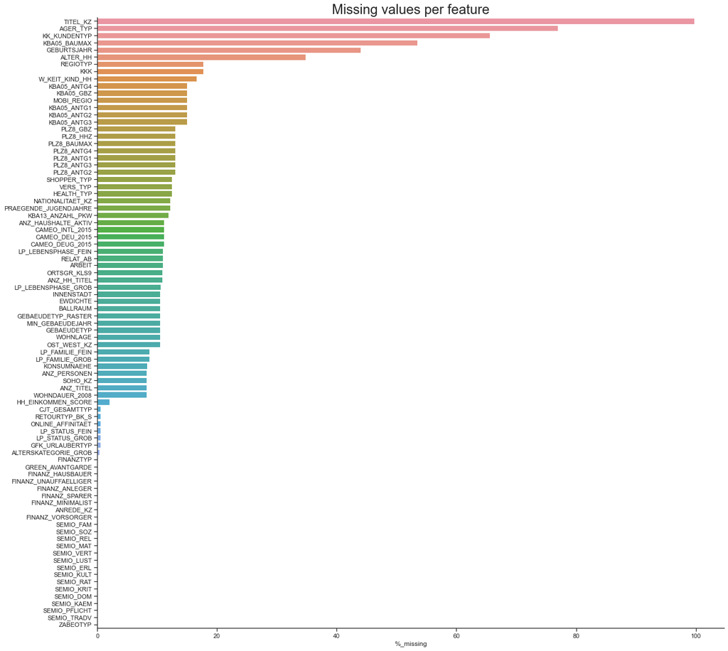

```python
# Investigate patterns in the amount of missing data in each column.
fig, _ = plt.subplots(figsize=(20,20))
sns.barplot(x='%_missing', y=data_nan.index, data=data_nan)
plt.title('Missing values per feature', fontsize=24)
plt.show()
```

As we will be working with the customer dataset at the end of this project, let's compare missing data ditributions between features to find out a comparable threshold when removing outliers.

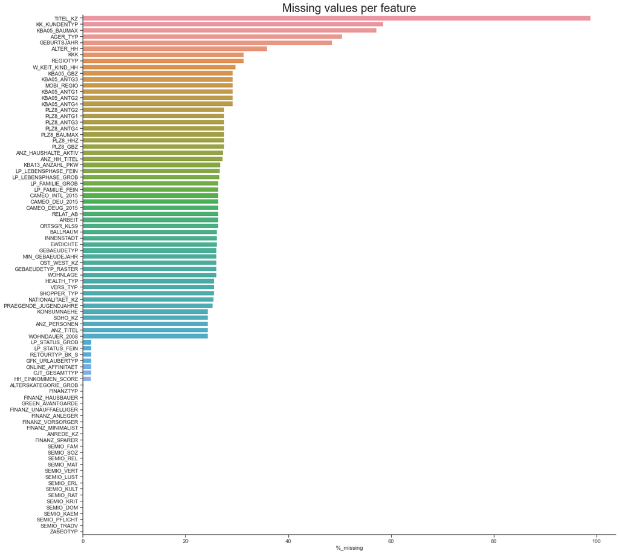

```python
# Load in the customer demographics data.
customers = pd.read_csv('Udacity_CUSTOMERS_Subset.csv', sep=';')
# Replace with NaNs all values per mapping in feat_info
customers_ = mapping_nan(customers, feat_info, 'attribute', 'missing_or_unknown', non_numerical_indicators=['X', 'XX'])
customers_nan=count_nan(customers_)
# Investigate patterns in the amount of missing data in each column.
fig, _ = plt.subplots(figsize=(20,20))
sns.barplot(x='%_missing', y=customers_nan.index, data=customers_nan)
plt.title('Missing values per feature', fontsize=24)
plt.show()
```

```python
customers_nan
```

|  | total_missing | %_missing |
| --- | --- | --- |
| TITEL_KZ | 189340 | 98.79 |
| KK_KUNDENTYP | 111937 | 58.41 |
| KBA05_BAUMAX | 109535 | 57.15 |
| AGER_TYP | 96738 | 50.48 |
| GEBURTSJAHR | 93024 | 48.54 |
| ALTER_HH | 68747 | 35.87 |
| KKK | 60064 | 31.34 |
| REGIOTYP | 60064 | 31.34 |
| W_KEIT_KIND_HH | 56937 | 29.71 |
| KBA05_GBZ | 55982 | 29.21 |
| KBA05_ANTG3 | 55980 | 29.21 |
| MOBI_REGIO | 55980 | 29.21 |
| KBA05_ANTG1 | 55980 | 29.21 |
| KBA05_ANTG2 | 55980 | 29.21 |
| KBA05_ANTG4 | 55980 | 29.21 |
| PLZ8_ANTG2 | 52764 | 27.53 |
| PLZ8_ANTG1 | 52764 | 27.53 |
| PLZ8_ANTG3 | 52764 | 27.53 |
| PLZ8_ANTG4 | 52764 | 27.53 |
| PLZ8_BAUMAX | 52764 | 27.53 |
| PLZ8_HHZ | 52764 | 27.53 |
| PLZ8_GBZ | 52764 | 27.53 |
| ANZ_HAUSHALTE_AKTIV | 52377 | 27.33 |
| ANZ_HH_TITEL | 52110 | 27.19 |
| KBA13_ANZAHL_PKW | 51281 | 26.76 |
| LP_LEBENSPHASE_FEIN | 51053 | 26.64 |
| LP_LEBENSPHASE_GROB | 50941 | 26.58 |
| LP_FAMILIE_GROB | 50582 | 26.39 |
| LP_FAMILIE_FEIN | 50582 | 26.39 |
| CAMEO_INTL_2015 | 50554 | 26.38 |

[output cut: 55 more lines]

```python
# Split the data into three categories:
    # High percentage of nans (>34%)
    # Moderate percentage of nans (15-34%)
    # Low percentage of nans (0-5%)
    # No nans
data_nan['nan_cat'] = pd.cut(data_nan['%_missing'],
                             bins=[-np.inf, 0, 15, 34, np.inf],
                             labels=['zero', 'low', 'moderate', 'high'])

#display head and tail(perc_missing is ordered)
display(data_nan.head())
display(data_nan.tail())
```

|  | total_missing | %_missing | information_level | nan_cat |
| --- | --- | --- | --- | --- |
| TITEL_KZ | 889061 | 99.76 | person | high |
| AGER_TYP | 685843 | 76.96 | person | high |
| KK_KUNDENTYP | 584612 | 65.60 | household | high |
| KBA05_BAUMAX | 476524 | 53.47 | microcell_rr3 | high |
| GEBURTSJAHR | 392318 | 44.02 | person | high |

|  | total_missing | %_missing | information_level | nan_cat |
| --- | --- | --- | --- | --- |
| SEMIO_DOM | 0 | 0.0 | person | zero |
| SEMIO_KAEM | 0 | 0.0 | person | zero |
| SEMIO_PFLICHT | 0 | 0.0 | person | zero |
| SEMIO_TRADV | 0 | 0.0 | person | zero |
| ZABEOTYP | 0 | 0.0 | person | zero |

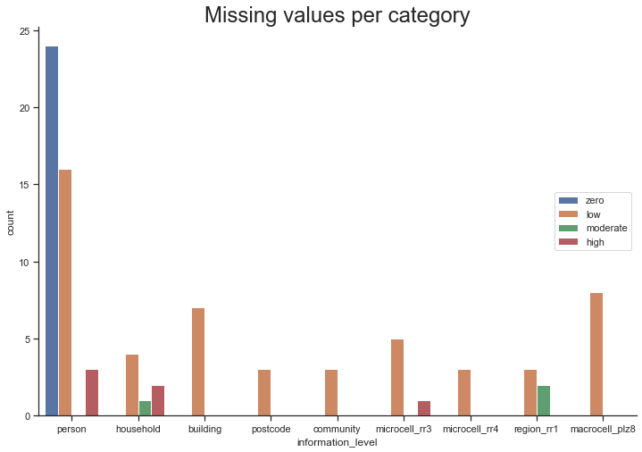

```python
order = ['person', 'household', 'building', 'postcode', 'community',
       'microcell_rr3', 'microcell_rr4', 'region_rr1', 'macrocell_plz8']
hue_order = ['zero', 'low', 'moderate', 'high']
sns.countplot(data=data_nan,
              x='information_level',
              hue='nan_cat',
              order=order,
              hue_order=hue_order)
plt.legend(loc='right')
plt.title('Missing values per category', fontsize=24)
plt.show()
```

```python
# Remove outlier columns from the dataset.
#features to remove: >34% of missing values
features_drop=data_nan.loc[data_nan['%_missing']>34].index.tolist()
print('Removing the following features from datasets:\n')
for i in features_drop:
    print('-',i)
#removing columns from azdias
azdias.drop(features_drop, axis=1, inplace=True)
#removing columns from feat_info
feat_info=feat_info.loc[~feat_info.attribute.isin(features_drop)]
feat_info.shape
```

```
Removing the following features from datasets:

- TITEL_KZ
- AGER_TYP
- KK_KUNDENTYP
- KBA05_BAUMAX
- GEBURTSJAHR
- ALTER_HH
```

```
(79, 4)
```

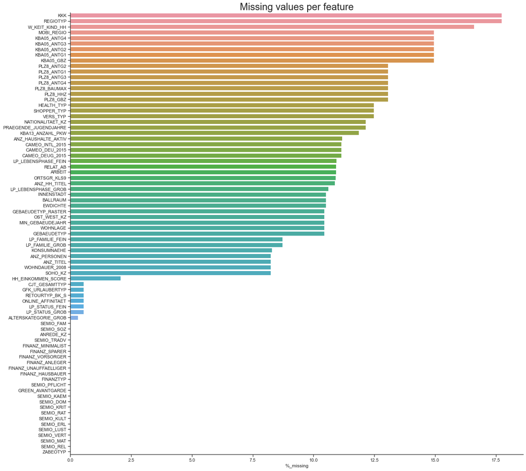

```python
data_nan=count_nan(azdias)
fig = plt.figure(figsize=(20,20))
sns.barplot(data=data_nan, x='%_missing', y=data_nan.index)
plt.title('Missing values per feature', fontsize=24)
plt.show()
```

#### Discussion 1.1.2: Assess Missing Data in Each Column

> - All missing values have been re-encoded in a consistent way as NaNs.
> - 24 columns without missing values
> - Removed 6 columns with more than 34% of missing values (TITEL_KZ, AGER_TYP, KK_KUNDENTY, KBA05_BAUMAX, GEBURTSJAHR, ALTER_HH), considered outliers.
> - Identified some patterns in missing values between other columns: Several groups (ANZ*, LP*, PLZ8_, KBA05) of 3-7 features with exactly the same number of missing values. Are there any patterns in these groups? "Understanding the reasons why data are missing is important for handling the remaining data correctly. If values are missing completely at random, the data sample is likely still representative of the population. But if the values are missing systematically, analysis may be biased. Missing completely at random (MCAR), Missing at random (MAR), Missing not at random (MNAR)" Wikipedia: Missing Data

#### Step 1.1.3: Assess Missing Data in Each Row

How much data is missing in each row? We'll divide the data into two subsets: one for data points that are above some threshold for missing values, and a second subset for points below that threshold.

In order to know what to do with the outlier rows, we should see if the distribution of data values on columns that are not missing data (or are missing very little data) are similar or different between the two groups.

Go back to Index

```python
# How much data is missing in each row of the dataset?
def count_nan_row (df):
    d={'total_missing':df.isnull().sum(axis=1).sort_values(ascending=False),'%_missing':np.round((df.isnull().mean(axis=1)*100).sort_values(ascending=False),2)}
    return(pd.DataFrame(d))
```

```python
data_nan_row=count_nan_row(azdias)

print(data_nan_row['%_missing'].max(), '% max missing values')
print(data_nan_row.total_missing.loc[data_nan_row.total_missing==0].count(),'observations with 0 missing values')
```

```
62.03 % max missing values
623209 observations with 0 missing values
```

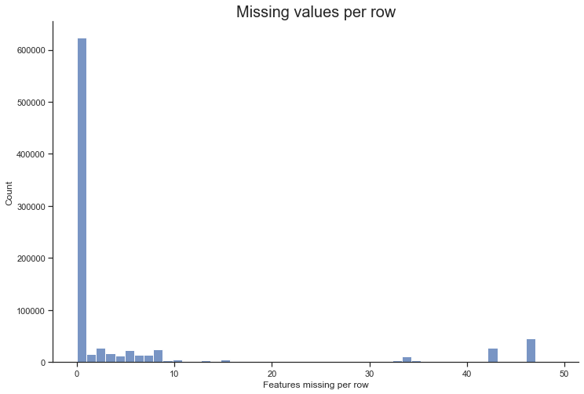

```python
sns.histplot(data_nan_row.total_missing, bins=50)
plt.title('Missing values per row', fontsize=20)
plt.xlabel('Features missing per row')
plt.show()
```

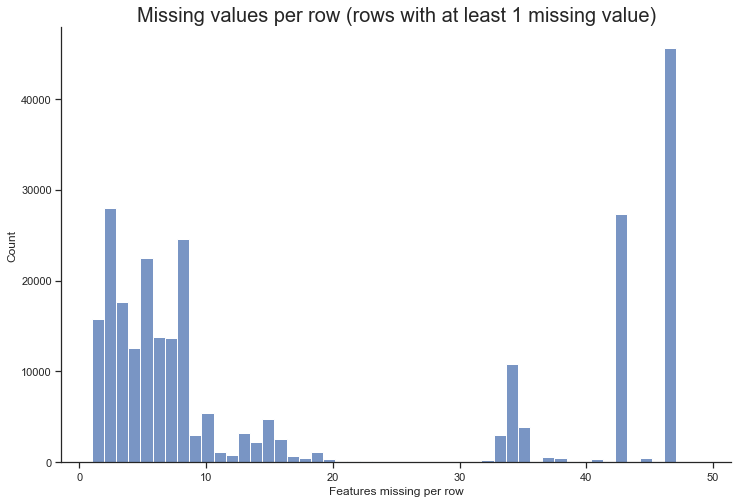

```python
sns.histplot(data_nan_row.total_missing.loc[data_nan_row.total_missing>0], bins=50)
plt.title('Missing values per row (rows with at least 1 missing value)', fontsize=20)
plt.xlabel('Features missing per row')
plt.show()
```

```python
# Write code to divide the data into two subsets based on the number of missing values in each row.
threshold=15
low_nan=azdias.loc[data_nan_row['%_missing']<threshold]
high_nan=azdias.loc[data_nan_row['%_missing']>threshold]
print(high_nan.shape, low_nan.shape)
```

```
(109941, 79) (781280, 79)
```

```python
# Compare the distribution of values for at least five columns where there are
# no or few missing values, between the two subsets.

def dist_threshold(cols_list, threshold, low_nan, high_nan):
    for col in cols_list:
        fig, (ax1, ax2) = plt.subplots(1, 2)
        #fig.set_title('Distribution of values per row, column {}\n\n'.format(col),fontsize=20)

        ax1.title.set_text('Low count: <{} missing values per row'.format(threshold))
        sns.countplot(low_nan[col], ax=ax1)

        ax2.title.set_text('High count: >{} missing values per row'.format(threshold))
        sns.countplot(high_nan[col], ax=ax2)

        plt.show()
```

```python
low_nan_cols=list(data_nan.index[-32:-24])
high_nan_cols=list(data_nan.index[:5])
print(low_nan_cols,'\n', high_nan_cols)
```

```
['HH_EINKOMMEN_SCORE', 'CJT_GESAMTTYP', 'GFK_URLAUBERTYP', 'RETOURTYP_BK_S', 'ONLINE_AFFINITAET', 'LP_STATUS_FEIN', 'LP_STATUS_GROB', 'ALTERSKATEGORIE_GROB']
 ['KKK', 'REGIOTYP', 'W_KEIT_KIND_HH', 'MOBI_REGIO', 'KBA05_ANTG4']
```

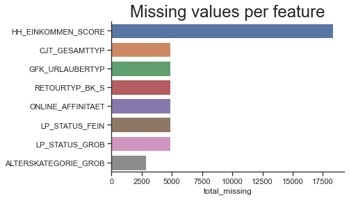

```python
fig=plt.figure(figsize=(6,4))
sns.barplot(data=data_nan[-32:-24], x='total_missing', y=data_nan.index[-32:-24])
plt.title('Missing values per feature', fontsize=24)
plt.show()
```

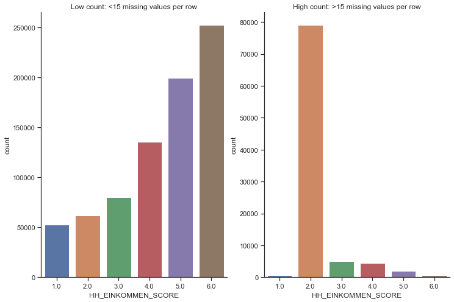

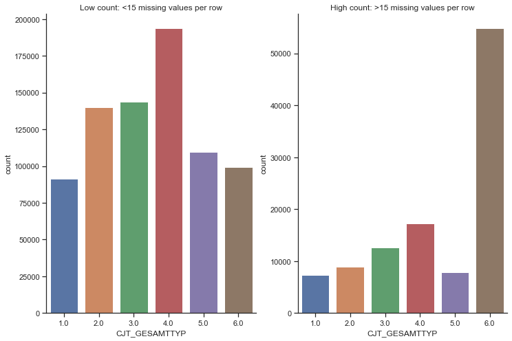

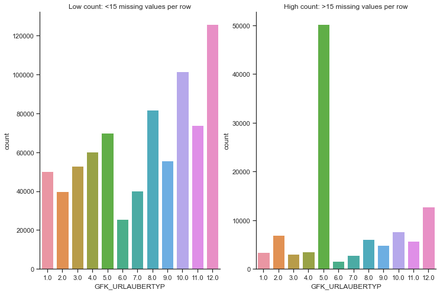

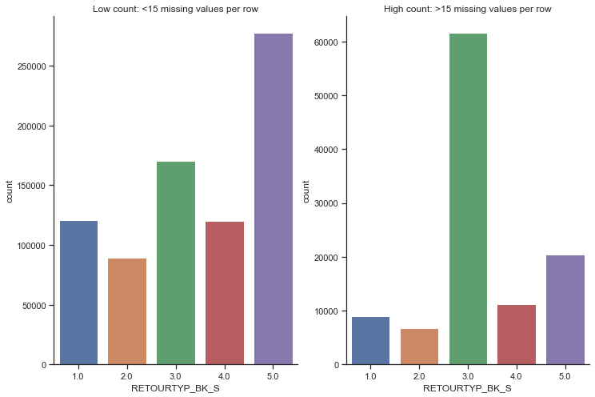

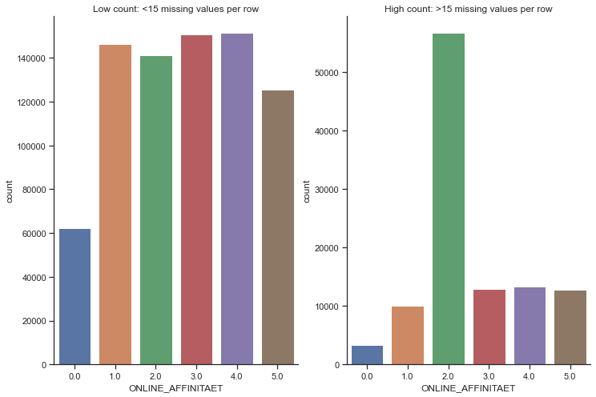

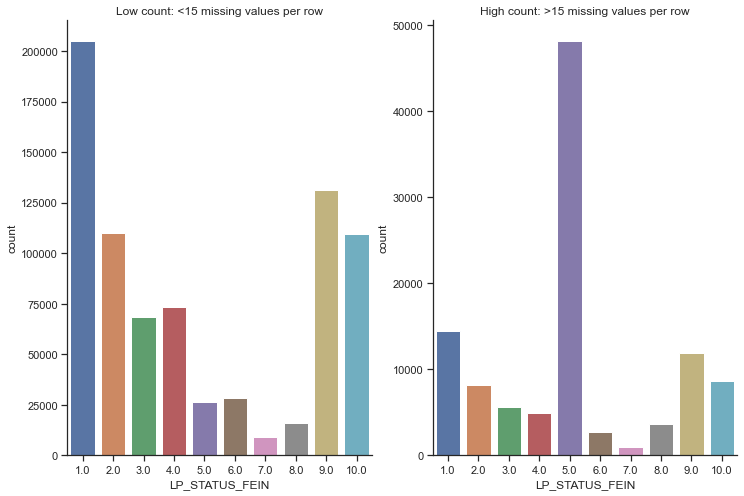

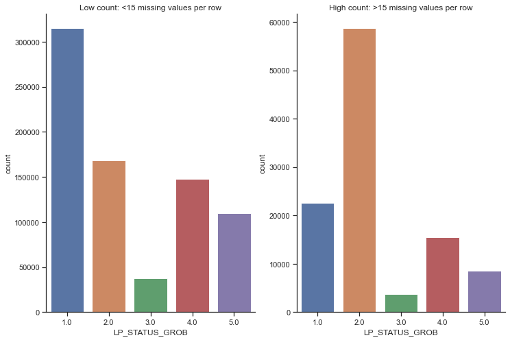

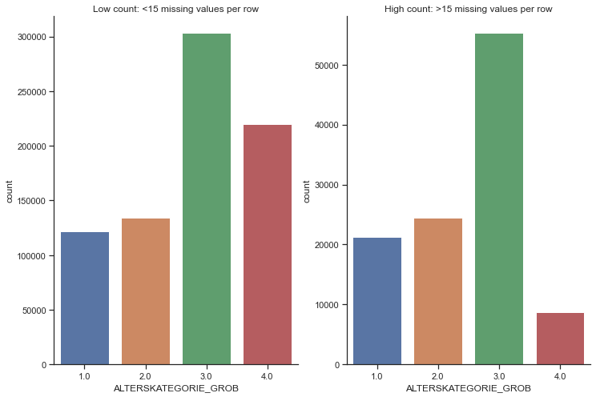

```python
dist_threshold(low_nan_cols, threshold, low_nan, high_nan)
```

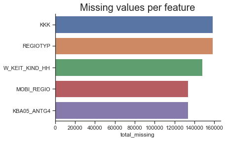

```python
fig=plt.figure(figsize=(6,4))
sns.barplot(data=data_nan[:5], x='total_missing', y=data_nan.index[:5])
plt.title('Missing values per feature', fontsize=20)
plt.show()
```

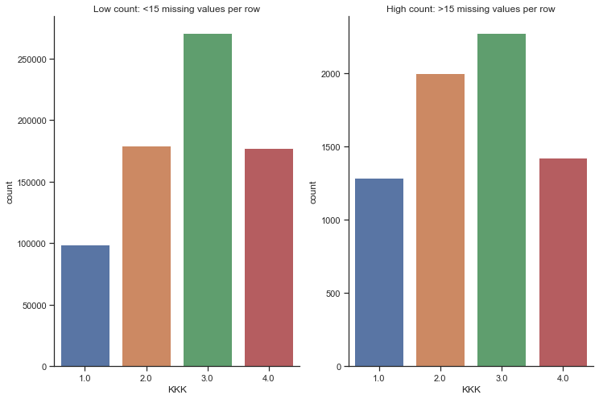

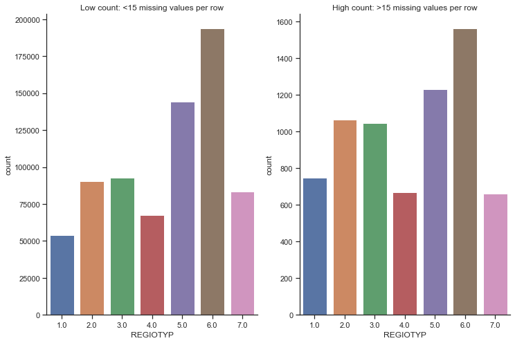

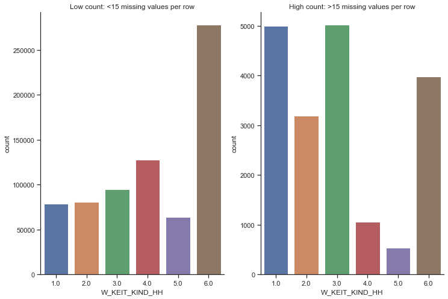

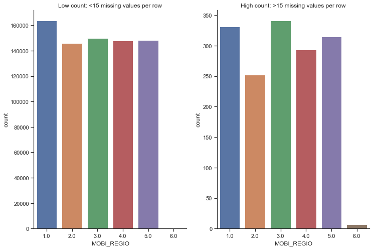

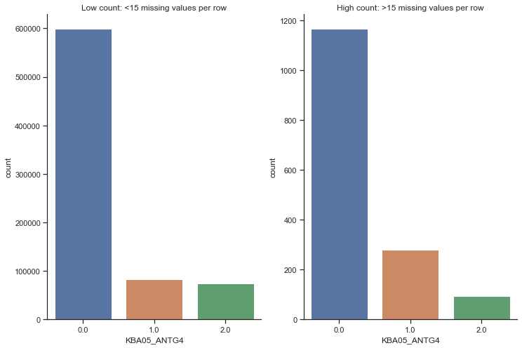

```python
dist_threshold(high_nan_cols, threshold, low_nan, high_nan)
```

#### Discussion 1.1.3: Assess Missing Data in Each Row

> - More than 600,000 observations without missing values (after removing features considered 'outliers')
> - Columns with low count of null values have different distributions between rows with >threshold missing values per value. Especifically, a category with outstanding count (x3-x5 comparing with other category values)
> - Except column W_KEIT_KIND_HH, other chosen columns (with high count of nans) distributions for observations with >threshold and < threshold of missing values are similar.
> - Tried threshold = [15,20,25]

> **If the distributions of non-missing features look similar between the data with many missing values and the data with few or no missing values, then we could argue that simply dropping those points from the analysis won't present a major issue. On the other hand, if the data with many missing values looks very different from the data with few or no missing values, then we should make a note on those data as special.** Looking at the overall visualizations above, I consider missing data as ¨special¨ and won´t be removed.

### Step 1.2: Select and Re-Encode Features

Checking for missing data isn't the only way in which a dataset can be prepared for analysis. Since the unsupervised learning techniques to be used will only work on data that is encoded numerically, we'll need to make a few encoding changes or additional assumptions to be able to make progress.

Go back to Index

```python
# How many features are there of each data type?
feat_info['type'].value_counts()
```

```
ordinal        49
categorical    18
mixed           6
numeric         6
Name: type, dtype: int64
```

> **Summary of types of measurement.**
> - For numeric and interval data, these features can be kept without changes.
> - Most of the variables in the dataset (49) are ordinal in nature. While ordinal values may technically be non-linear in spacing, we'll make the simplifying assumption that the ordinal variables can be treated as being interval in nature (that is, kept without any changes).
> - Special handling may be necessary for the remaining two variable types: categorical, and 'mixed'.